# FigureYa112Plus_venn

## 四个圈

以SKCM_deseq2_test_result.immune_vs_Others.txt和SKCM_edgeR_test_result.immune_vs_Others.txt为例，把上调和下调拆开，展示在两种方法中都被筛到的差异基因。

## Four circles

Taking SKCM_deseq2_test_desult.immune-vs_Others.txt and SKCM_ edgeR_test_desult.immune-vs_Others.txt as examples, the upregulation and downregulation were separated to display the differentially expressed genes screened in both methods.

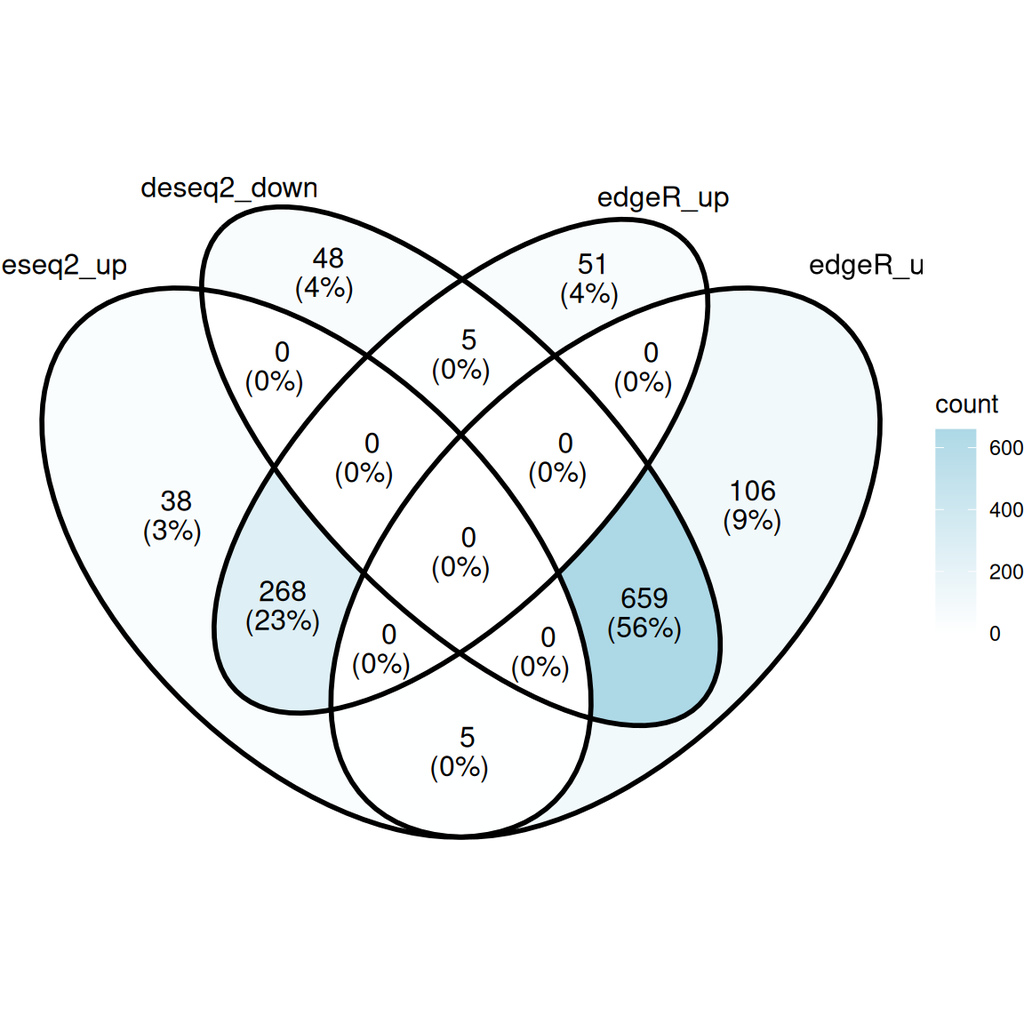

```r
file1 <- "SKCM_deseq2_test_result.immune_vs_Others.txt"
file2 <- "SKCM_edgeR_test_result.immune_vs_Others.txt"
list_ID <- list(deseq2_up = read_cut_updown(file1)$up,
                deseq2_down = read_cut_updown(file1)$down,
                edgeR_up = read_cut_updown(file2)$up,
                edgeR_up = read_cut_updown(file2)$down
)

# 画venn图
p <- ggVennDiagram(list_ID, label_alpha=0) +
  scale_fill_gradient(low="white", high = "lightblue")
p
```

```r
# 保存成pdf文件
ggsave("venn_4.pdf", width = 6, height = 6)

# 保存到ppt里
graph2ppt(p, file="venn_4.pptx",width = 6,height = 6)
```

```
## Exported graph as venn_4.pptx
```

```r
# 把各区域的基因输出到文件
venn_list <- list_ID
intersect_1_2 <- intersect(venn_list[[1]], venn_list[[2]])
write.xlsx(list(Intersect_1_2 = intersect_1_2), "venn_4.xlsx")
```

## 三个圈

对比三个文件

以DESeq2获得的三种差异表达基因为例，展示其overlap

## Three circles

Compare three files

Taking the three differentially expressed genes obtained from DESeq2 as an example, demonstrate their overlap

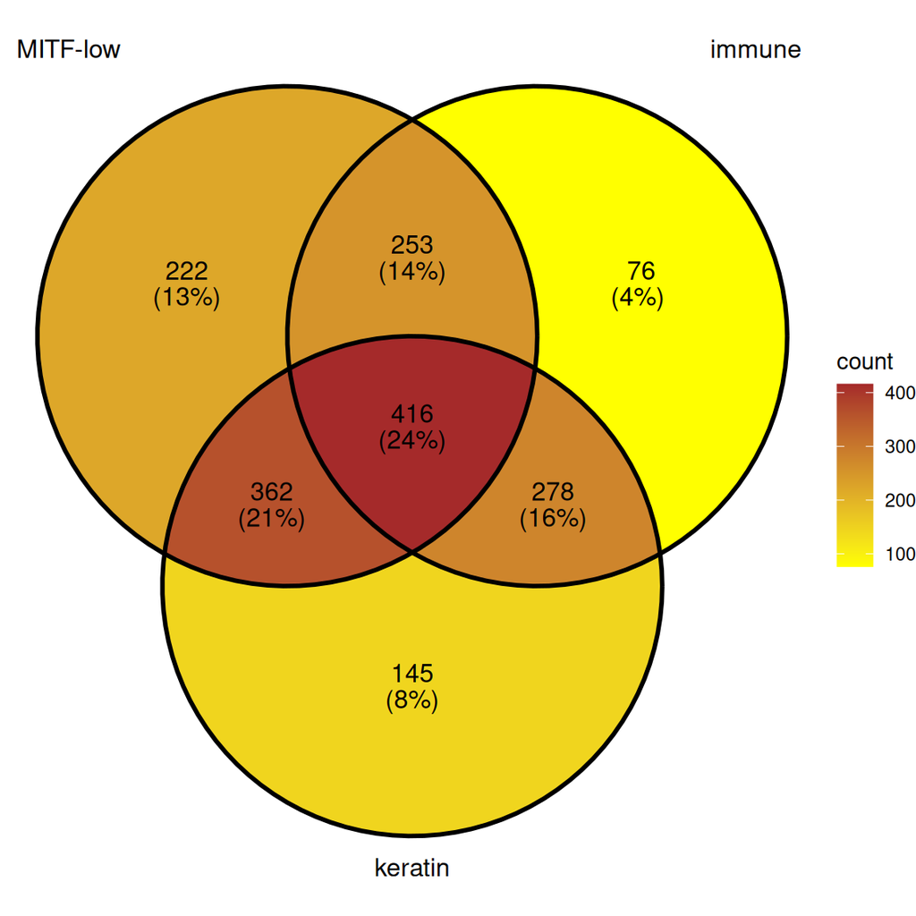

```r
# 读取带有deseq2的文件，筛选差异基因
list_ID <- lapply(finfo[finfo$method == "deseq2", ]$file, read_cut_ID)
names(list_ID) <- str_remove(finfo[finfo$method == "deseq2",]$group, "_vs_Others")

# 画venn图，这次换个配色
p <- ggVennDiagram(list_ID, label_alpha=0) +
  scale_fill_gradient(low="yellow", high = "brown")
p
```

```r
# 保存成pdf文件
ggsave(paste0("venn_3.pdf"), width = 6, height = 6)

# 保存到ppt里
graph2ppt(p, file="venn_3.pptx",width = 6,height = 6)
```

```
## Exported graph as venn_3.pptx
```

```r
# 把各区域的基因输出到文件
venn_list <- list_ID
intersect_1_2 <- intersect(venn_list[[1]], venn_list[[2]])
write.xlsx(list(Intersect_1_2 = intersect_1_2), "venn_3.xlsx")
```